# index

## Q9. Credit history could be an important variable predicting whether people will fulfill the credit agreement, so find out any relationship between history and response. You need to develop two plots here.

#### 1st plot simply shows how many people per each category;

```python
# shows the number of people from each HISTORY category that took out a loan
response_count = df.groupby('HISTORY').size()

# shows the total number of people that paid back their loan from each HISTORY category according to response
response_sum = df.groupby('HISTORY').RESPONSE.sum()

print(response_count)
print("-----------------------------------------------------------")
print(response_sum)
```

```
HISTORY
0     40
1     49
2    530
3     88
4    293
dtype: int64
-----------------------------------------------------------
HISTORY
0     15
1     21
2    361
3     60
4    243
Name: RESPONSE, dtype: int64
```

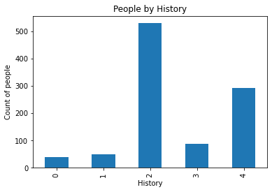

```python
response_count.plot(kind='bar')
plt.xlabel('History')
plt.ylabel('Count of people')
plt.title("People by History")
```

#### 2nd plot shows the "probability" of loan payback in terms of "history".

```python
response_prob=response_sum/response_count
print(response_prob)
```

```
HISTORY
0    0.375000
1    0.428571
2    0.681132
3    0.681818
4    0.829352
dtype: float64
```

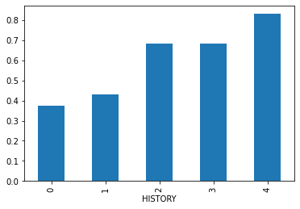

```python
response_prob.plot(kind='bar')
```

#### Provide a discussion of the findings in a markdown

- History category 2 has a large number of people who take loans but history category 4 has the highest probability of paying back their loans.

## Q10. Formulate your own question relevant to this dataset and business problem and answer using data visualization.

#### What is the probability of people who paid back their loans in terms of every employment category

```python
# total number of people that asked for a loan in each category of EMPLOYMENT
client_count=df.groupby('EMPLOYMENT').size()

# total number of people that paid back their loan in each category of EMPLOYMENT according to RESPONSE
payback_sum=df.groupby('EMPLOYMENT').RESPONSE.sum()

print(client_count)
print("-----------------------------------------------------------")
print(payback_sum)
```

```
EMPLOYMENT
0     62
1    172
2    339
3    174
4    253
dtype: int64
-----------------------------------------------------------
EMPLOYMENT
0     39
1    102
2    235
3    135
4    189
Name: RESPONSE, dtype: int64
```

```python
payback_prob=payback_sum/client_count
print(payback_prob)
```

```
EMPLOYMENT
0    0.629032
1    0.593023
2    0.693215
3    0.775862
4    0.747036
dtype: float64
```

#### Make a that plot shows the "probability" of loan payback in terms of "EMPLOYMENT"

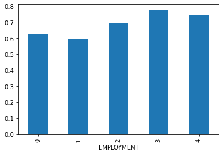

```python
payback_prob.plot(kind='bar');
```

## Q11. By Using seaborn, make a joint plot to show relationship between DURATION, AGE, and the type of JOB loan seekers have..

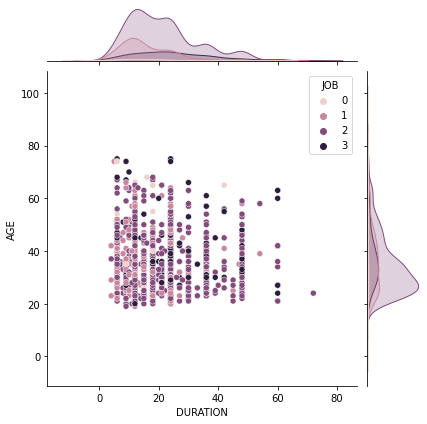

```python
sns.jointplot(data=df, x="DURATION", y="AGE", hue="JOB")
```